# Ch8 Themes

## Theme elements

There are around 40 unique elements that control the appearance of the plot. They can be roughly grouped into five categories: plot, axis, legend, panel and facet. The following sections describe each in turn.

### Plot elements

Some elements affect the plot as a whole:

| Element | Setter | Description |
| --- | --- | --- |
| plot.background | `element_rect()` | plot background |
| plot.title | `element_text()` | plot title |
| plot.margin | `margin()` | margins around plot |

`plot.background` draws a rectangle that underlies everything else on the plot. By default, ggplot2 uses a white background which ensures that the plot is usable wherever it might end up (e.g. even if you save as a png and put on a slide with a black background). When exporting plots to use in other systems, you might want to make the background transparent with `fill = NA`. Similarly, if you’re embedding a plot in a system that already has margins you might want to eliminate the built-in margins. Note that a small margin is still necessary if you want to draw a border around the plot.

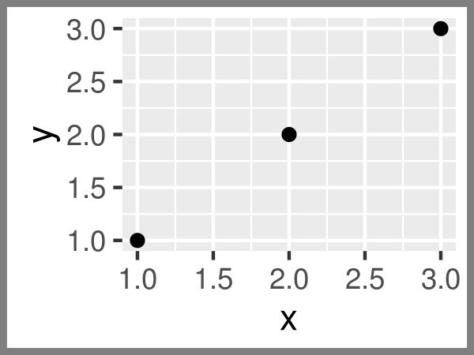

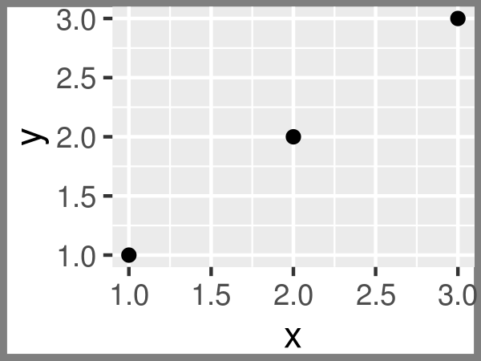

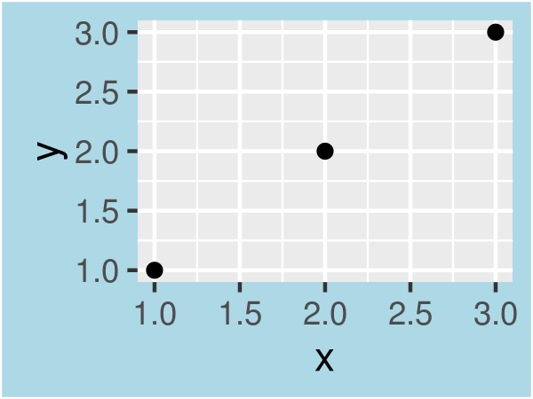

```r
base + theme(plot.background = element_rect(colour = "grey50", size = 2))
base + theme(
  plot.background = element_rect(colour = "grey50", size = 2),
  plot.margin = margin(2, 2, 2, 2)
)
base + theme(plot.background = element_rect(fill = "lightblue"))
```

### Axis elements

The axis elements control the apperance of the axes:

| Element | Setter | Description |
| --- | --- | --- |
| axis.line | `element_line()` | line parallel to axis (hidden in default themes) |
| axis.text | `element_text()` | tick labels |
| axis.text.x | `element_text()` | x-axis tick labels |
| axis.text.y | `element_text()` | y-axis tick labels |
| axis.title | `element_text()` | axis titles |
| axis.title.x | `element_text()` | x-axis title |
| axis.title.y | `element_text()` | y-axis title |
| axis.ticks | `element_line()` | axis tick marks |
| axis.ticks.length | `unit()` | length of tick marks |

Note that `axis.text` (and `axis.title`) comes in three forms: `axis.text`, `axis.text.x`, and `axis.text.y`. Use the first form if you want to modify the properties of both axes at once: any properties that you don’t explicitly set in `axis.text.x` and `axis.text.y` will be inherited from `axis.text`.

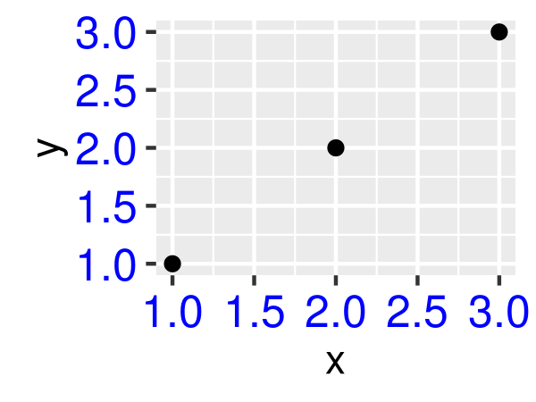

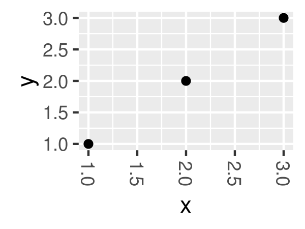

```r
df <- data.frame(x = 1:3, y = 1:3)
base <- ggplot(df, aes(x, y)) + geom_point()

# Accentuate the axes
base + theme(axis.line = element_line(colour = "grey50", size = 1))
# Style both x and y axis labels
base + theme(axis.text = element_text(color = "blue", size = 12))
# Useful for long labels
base + theme(axis.text.x = element_text(angle = -90, vjust = 0.5))
```

[output not shown]

The most common adjustment is to rotate the x-axis labels to avoid long overlapping labels. If you do this, note negative angles tend to look best and you should set `hjust = 0` and `vjust = 1`:

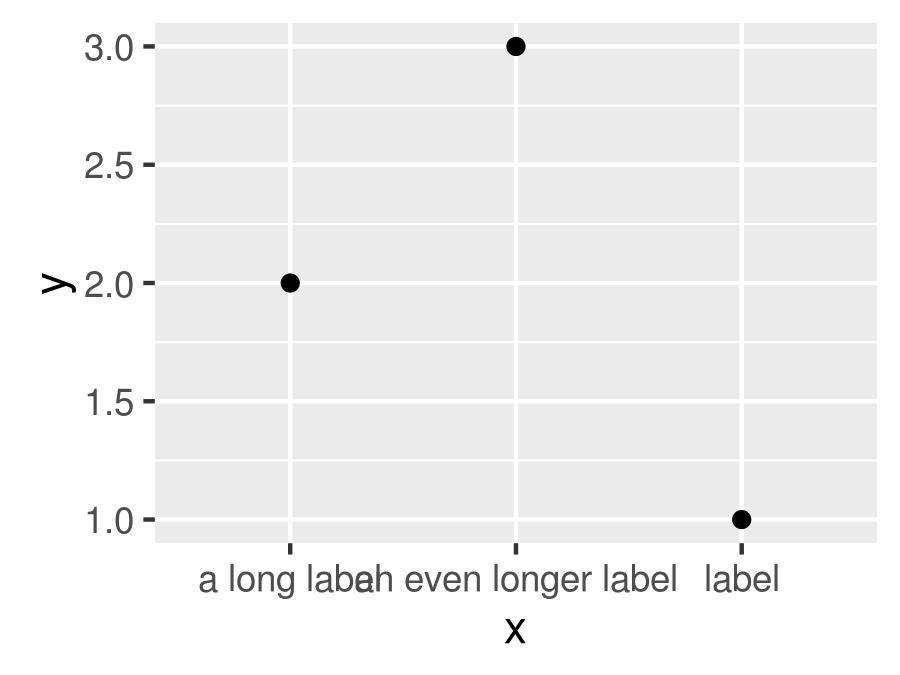

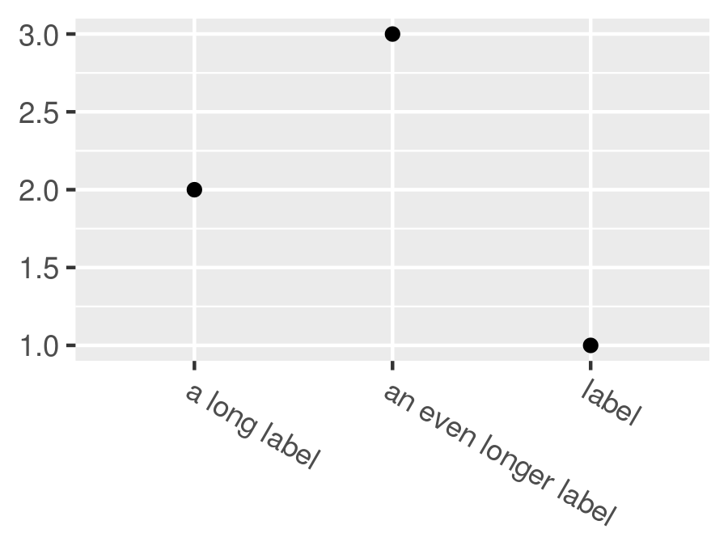

```r
df <- data.frame(
  x = c("label", "a long label", "an even longer label"),
  y = 1:3
)
base <- ggplot(df, aes(x, y)) + geom_point()
base
base +
  theme(axis.text.x = element_text(angle = -30, vjust = 1, hjust = 0)) +
  xlab(NULL) +
  ylab(NULL)
```

### Legend elements

The legend elements control the apperance of all legends. You can also modify the appearance of individual legends by modifying the same elements in `guide_legend()` or `guide_colourbar()`.

| Element | Setter | Description |
| --- | --- | --- |
| legend.background | `element_rect()` | legend background |
| legend.key | `element_rect()` | background of legend keys |
| legend.key.size | `unit()` | legend key size |
| legend.key.height | `unit()` | legend key height |
| legend.key.width | `unit()` | legend key width |
| legend.margin | `unit()` | legend margin |
| legend.text | `element_text()` | legend labels |
| legend.text.align | 0–1 | legend label alignment (0 = right, 1 = left) |
| legend.title | `element_text()` | legend name |
| legend.title.align | 0–1 | legend name alignment (0 = right, 1 = left) |

These options are illustrated below:

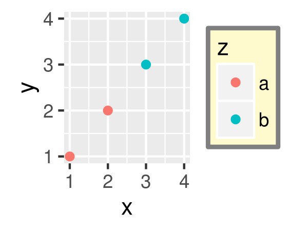

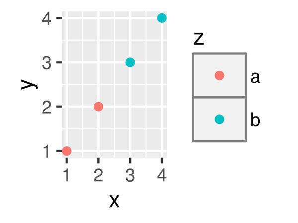

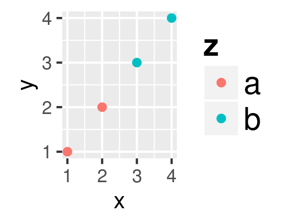

```r
df <- data.frame(x = 1:4, y = 1:4, z = rep(c("a", "b"), each = 2))
base <- ggplot(df, aes(x, y, colour = z)) + geom_point()

base + theme(
  legend.background = element_rect(
    fill = "lemonchiffon",
    colour = "grey50",
    size = 1
  )
)
base + theme(
  legend.key = element_rect(color = "grey50"),
  legend.key.width = unit(0.9, "cm"),
  legend.key.height = unit(0.75, "cm")
)
base + theme(
  legend.text = element_text(size = 15),
  legend.title = element_text(size = 15, face = "bold")
)
```

There are four other properties that control how legends are laid out in the context of the plot (`legend.position`, `legend.direction`, `legend.justification`, `legend.box`). They are described in legend layout.

### Panel elements

Panel elements control the appearance of the plotting panels:

| Element | Setter | Description |
| --- | --- | --- |
| panel.background | `element_rect()` | panel background (under data) |
| panel.border | `element_rect()` | panel border (over data) |
| panel.grid.major | `element_line()` | major grid lines |
| panel.grid.major.x | `element_line()` | vertical major grid lines |
| panel.grid.major.y | `element_line()` | horizontal major grid lines |
| panel.grid.minor | `element_line()` | minor grid lines |
| panel.grid.minor.x | `element_line()` | vertical minor grid lines |
| panel.grid.minor.y | `element_line()` | horizontal minor grid lines |
| aspect.ratio | numeric | plot aspect ratio |

The main difference between `panel.background` and `panel.border` is that the background is drawn underneath the data, and the border is drawn on top of it. For that reason, you’ll always need to assign `fill = NA` when overriding `panel.border`.

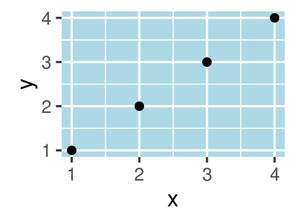

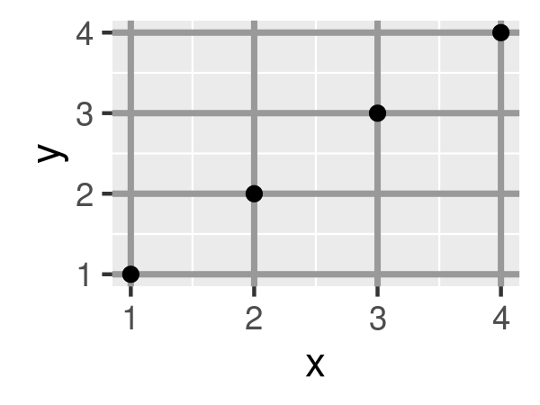

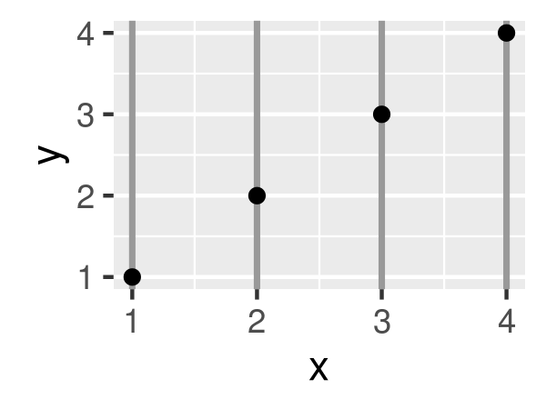

```r
base <- ggplot(df, aes(x, y)) + geom_point()
# Modify background
base + theme(panel.background = element_rect(fill = "lightblue"))

# Tweak major grid lines
base + theme(
  panel.grid.major = element_line(color = "gray60", size = 0.8)
)
# Just in one direction
base + theme(
  panel.grid.major.x = element_line(color = "gray60", size = 0.8)
)
```

Note that aspect ratio controls the aspect ratio of the *panel*, not the overall plot:

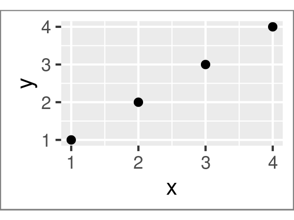

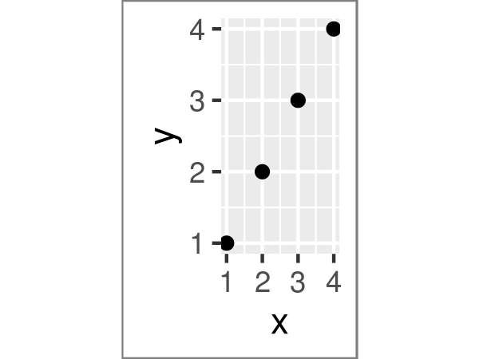

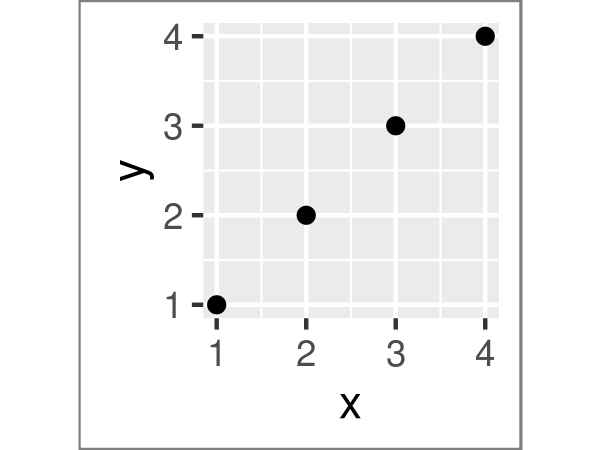

```r
base2 <- base + theme(plot.background = element_rect(colour = "grey50"))
# Wide screen
base2 + theme(aspect.ratio = 9 / 16)
# Long and skiny
base2 + theme(aspect.ratio = 2 / 1)
# Square
base2 + theme(aspect.ratio = 1)
```

### Facetting elements

The following theme elements are associated with faceted ggplots:

| Element | Setter | Description |
| --- | --- | --- |
| strip.background | `element_rect()` | background of panel strips |
| strip.text | `element_text()` | strip text |
| strip.text.x | `element_text()` | horizontal strip text |
| strip.text.y | `element_text()` | vertical strip text |
| panel.margin | `unit()` | margin between facets |
| panel.margin.x | `unit()` | margin between facets (vertical) |
| panel.margin.y | `unit()` | margin between facets (horizontal) |

Element `strip.text.x` affects both `facet_wrap()` or `facet_grid()`; `strip.text.y` only affects `facet_grid()`.

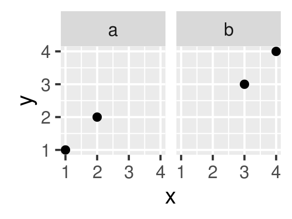

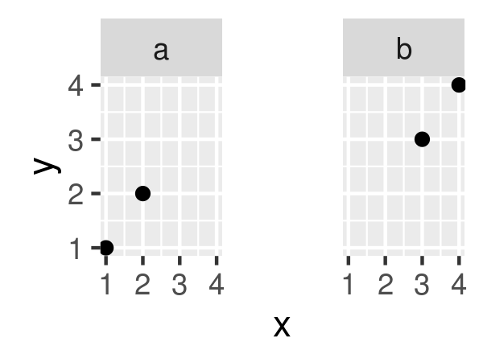

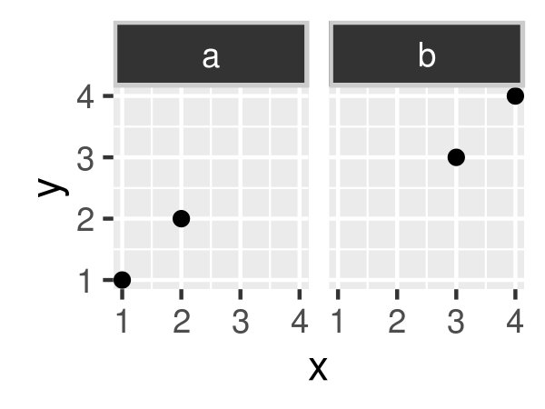

```r
df <- data.frame(x = 1:4, y = 1:4, z = c("a", "a", "b", "b"))
base_f <- ggplot(df, aes(x, y)) + geom_point() + facet_wrap(~z)

base_f
base_f + theme(panel.margin = unit(0.5, "in"))
base_f + theme(
  strip.background = element_rect(fill = "grey20", color = "grey80", size = 1),
  strip.text = element_text(colour = "white")
)
```

### Exercises

1. Create the ugliest plot possible! (Contributed by Andrew D. Steen, University of Tennessee - Knoxville)
2. `theme_dark()` makes the inside of the plot dark, but not the outside. Change the plot background to black, and then update the text settings so you can still read the labels.
3. Make an elegant theme that uses “linen” as the background colour and a serif font for the text.
4. Systematically explore the effects of `hjust` when you have a multiline title. Why doesn’t `vjust` do anything?

## Saving your output

When saving a plot to use in another program, you have two basic choices of output: raster or vector:

- Vector graphics describe a plot as sequence of operations: draw a line from $(x_1, y_1)$ to $(x_2, y_2)$, draw a circle at $(x_3, x_4)$ with radius $r$. This means that they are effectively ‘infinitely’ zoomable; there is no loss of detail. The most useful vector graphic formats are pdf and svg.
- Raster graphics are stored as an array of pixel colours and have a fixed optimal viewing size. The most useful raster graphic format is png.

Unless there is a compelling reason not to, use vector graphics: they look better in more places. There are two main reasons to use raster graphics:

- You have a plot (e.g. a scatterplot) with thousands of graphical objects (i.e. points). A vector version will be large and slow to render.
- You want to embed the graphic in MS Office. MS has poor support for vector graphics (except for their own DrawingXML format which is not currently easy to make from R), so raster graphics are easier.

There are two ways to save output from ggplot2. You can use the standard R approach where you open a graphics device, generate the plot, then close the device:

```r
pdf("output.pdf", width = 6, height = 6)
ggplot(mpg, aes(displ, cty)) + geom_point()
dev.off()
```

This works for all packages, but is verbose. ggplot2 provides a convenient shorthand with `ggsave()`:

```r
ggplot(mpg, aes(displ, cty)) + geom_point()
ggsave("output.pdf")
```

`ggsave()` is optimised for interactive use: you can use it after you’ve drawn a plot. It has the following important arguments:

- The first argument, `path`, specifies the path where the image should be saved. The file extension will be used to automatically select the correct graphics device. `ggsave()` can produce `.eps`, `.pdf`, `.svg`, `.wmf`, `.png`, `.jpg`, `.bmp`, and `.tiff`.
- `width` and `height` control the output size, specified in inches. If left blank, they’ll use the size of the on-screen graphics device.
- For raster graphics (i.e. `.png`, `.jpg`), the `dpi` argument controls the resolution of the plot. It defaults to 300, which is appropriate for most printers, but you may want to use 600 for particularly high-resolution output, or 96 for on-screen (e.g., web) display.

See `?ggsave` for more details.

## References

Brewer, Cynthia A. 1994. “Color Use Guidelines for Mapping and Visualization.” In *Visualization in Modern Cartography*, edited by A.M. MacEachren and D.R.F. Taylor, 123–47. Elsevier Science.

Carr, Dan. 1994. “Using Gray in Plots.” *ASA Statistical Computing and Graphics Newsletter* 2 (5): 11–14. http://www.galaxy.gmu.edu/~dcarr/lib/v5n2.pdf.

———. 2002. “Graphical Displays.” In *Encyclopedia of Environmetrics*, edited by Abdel H. El-Shaarawi and Walter W. Piegorsch, 2:933–60. John Wiley & Sons. http://www.galaxy.gmu.edu/~dcarr/lib/EnvironmentalGraphics.pdf.

Carr, Dan, and Ru Sun. 1999. “Using Layering and Perceptual Grouping in Statistical Graphics.” *ASA Statistical Computing and Graphics Newsletter* 10 (1): 25–31.

Cleveland, William. 1993. “A Model for Studying Display Methods of Statistical Graphics.” *Journal of Computational and Graphical Statistics* 2: 323–64. http://stat.bell-labs.com/doc/93.4.ps.

Tufte, Edward R. 2006. *Beautiful Evidence*. Graphics Press.